# Tugas Sistem Informasi Manajemen : Insight Data Coffe Chain Set

Muhammad Rifqi Farrel Arrafi

2026-04-16

[output not shown]

# Latar belakang :

##Dalam data Coffe Chain set, produk-produk yang ada memiliki catatan penjualan setiap awal bulannya. Hal itu menjadi suatu insight yang menarik untuk dibahas karena dapat menjadi pertimbangan dalam pengambilan keputusan. Setiap jenis produk terdapat dugaan bahwa memiliki pola tertentu.

# Rumusan Masalah :

## 1) Apakah tipe produk kopi dan teh mengalami pola kenaikan, penurunan, atau stagnan di musim tertentu?

## 2) Bagaimana efektivitas marketing terhadap profit di bulan/musim tertentu pada saat produk mengalami puncak penjualan?

# A. Koneksi SQL ke RStudio

```r
library(odbc)
library(DBI)
odbcListDrivers()
```

[output not shown]

[output cut: 47 more lines]

```r
dbConnect(odbc(),
          Driver = "MySQL ODBC 8.0 ANSI Driver",
          Server = "127.0.0.1",
          UID = "root",
          PWD = "farelarrafi445",
          Port = "3306")
```

```
## <OdbcConnection> root@127.0.0.1 via TCP/IP
##   Database: null
##   MySQL Version: 8.0.43
```

```r
con1 = dbConnect(odbc(),
                 Driver = "MySQL ODBC 8.0 ANSI Driver",
                 Server = "127.0.0.1",
                 UID = "root",
                 PWD = "farelarrafi445",
                 Port = "3306")

con2 = dbConnect(odbc(),
                 Driver = "MySQL ODBC 8.0 ANSI Driver",
                 Server = "127.0.0.1",
                 UID = "root",
                 PWD = "farelarrafi445",
                 Port = "3306",
                 Database = "coffechains")
```

# # C. Analisis rumusan masalah

## 1) Apakah profit penjualan tiap tipe produk kopi dan teh mengalami pola kenaikan, penurunan, atau stagnan di musim tertentu?

```r
#Dataset total pendapatan tipe produk Kopi selama 2013
dataset_kopi_teh <- dbGetQuery(con2, "select monthname(Tanggal), Jenis_produk, sum(Penjualan) as total_pendapatan from (select f.`Date` as Tanggal, f.ProductId, p.`Product Type` as Jenis_produk, p.Product, sum(f.Sales) as Penjualan from facttable f
join product p on f.ProductId = p.ProductId
where p.`Product Type` in ('Tea', 'Coffee') and year(f.Date) = 2013
group by p.Product, f.ProductId, p.`Product Type`, Tanggal
order by f.ProductId) as total_penjualan_teh
group by Jenis_produk, Tanggal;")


#Total pendapatan produk kopi dan teh
dataset_kopi_teh
```

```
##    monthname(Tanggal) Jenis_produk total_pendapatan
## 1            February       Coffee             8872
## 2             October       Coffee             8909
## 3             January       Coffee             9305
## 4           September       Coffee             9426
## 5                 May       Coffee             8865
## 6              August       Coffee             9702
## 7            December       Coffee             9350
## 8               March       Coffee             8958
## 9                July       Coffee             9821
## 10           November       Coffee             8759
## 11              April       Coffee             9257
## 12               June       Coffee             9470
## 13            October          Tea             7472
## 14          September          Tea             7607
## 15           February          Tea             7201
## 16                May          Tea             7098
## 17            January          Tea             7444
## 18              March          Tea             7255
## 19             August          Tea             7474
## 20           November          Tea             7123
## 21           December          Tea             7497
## 22               July          Tea             7400
## 23               June          Tea             7290
## 24              April          Tea             7378
```

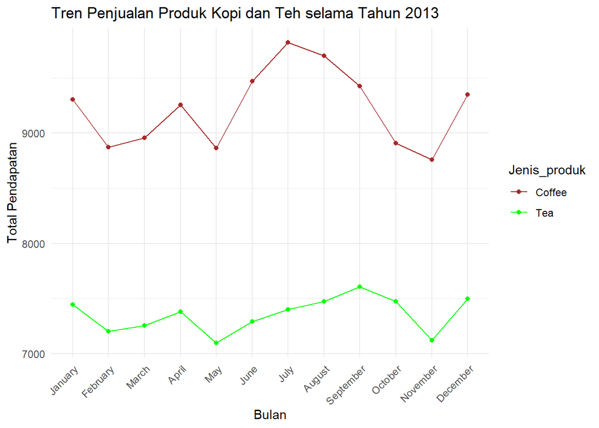

```r
#Urutan dataset berdasarkan bulan
dataset_kopi_teh$`monthname(Tanggal)` <- factor(dataset_kopi_teh$`monthname(Tanggal)`, levels = month.name)

#Line chart untuk melihat tren penjualan produk kopi dan teh selama tahun 2013
library(ggplot2)
timeseries_line <- ggplot(dataset_kopi_teh, aes(x = `monthname(Tanggal)`, y = total_pendapatan, group = Jenis_produk, color = Jenis_produk)) +
  geom_line() +
  geom_point() +
  labs(title = "Tren Penjualan Produk Kopi dan Teh selama Tahun 2013",
       x = "Bulan",
       y = "Total Pendapatan") +
  theme_minimal() +
  scale_color_manual(values = c("Coffee" = "brown", "Tea" = "green")) +
  theme(axis.text.x = element_text(angle = 45, hjust = 1))

timeseries_line
```

#Interpretasi grafik : Tren pendapatan produk Kopi dan Teh mempunyai pola yang cenderung mirip, tetapi sedikit berbeda. Kemiripan pola dapat dilihat dari pola pada awal tahun (bulan Januari - April). Pendapatan kedua produk mengalami penurunan pada bulan Februari karena berakhirnya musim dingin. Pendapatan perlahan mengalami kenaikan hingga bulan April, kemudian pendapatan turun di bulan Mei. Puncak pendapatan kedua produk berada di bulan yang berbeda, produk kopi mengalami puncak penjualan di bulan Juli, sedangkan produk Teh mengalami puncak penjualan di bulan September.Selain pola tersebut, pola yang cukup menarik dari kedua produk dapat ditinjau di penjualan akhir tahun (bulan November-Desember). Pola tersebut mungkin disebabkan karena adanya musim dingin / salju yang menyebabkan banyak masyarakat mulai mengonsumsi minuman hangat, dalam hal ini adalah produk kopi dan teh.

# Uji Normalitas Shapiro Wilk Data Produk Kopi dan Teh

##Uji normalitas antara 2 data produk bertujuan untuk mengetahui normalitas kedua data dan menentukan uji yang sesuai dengan normalitasnya (parametrik jika normal dan nonparametrik jika tidak normal)

```r
dataset_kopi <- dbGetQuery(con2,"select monthname(Tanggal), Jenis_produk, sum(Penjualan) as total_pendapatan from (select f.`Date` as Tanggal, f.ProductId, p.`Product Type` as Jenis_produk, p.Product, sum(f.Sales) as Penjualan from facttable f
join product p on f.ProductId = p.ProductId
where p.`Product Type` in ('Coffee') and year(f.Date) = 2013
group by p.Product, f.ProductId, p.`Product Type`, Tanggal
order by f.ProductId) as total_penjualan_teh
group by Jenis_produk, Tanggal;")

dataset_teh <- dbGetQuery(con2,"select monthname(Tanggal), Jenis_produk, sum(Penjualan) as total_pendapatan from (select f.`Date` as Tanggal, f.ProductId, p.`Product Type` as Jenis_produk, p.Product, sum(f.Sales) as Penjualan from facttable f
join product p on f.ProductId = p.ProductId
where p.`Product Type` in ('Tea') and year(f.Date) = 2013
group by p.Product, f.ProductId, p.`Product Type`, Tanggal
order by f.ProductId) as total_penjualan_teh
group by Jenis_produk, Tanggal;")


#Uji normalitas dataset kopi
uji_normalitas_kopi <- shapiro.test(dataset_kopi$total_pendapatan)
#Interpretasi hasil uji
cat(ifelse(uji_normalitas_kopi$p.value > 0.05, "Data Produk Kopi Berdistribusi Normal", "Data Produk Kopi Tidak Berdistribusi Normal"))
```

```
## Data Produk Kopi Berdistribusi Normal
```

```r
#Uji normalitas dataset teh
uji_normalitas_teh <- shapiro.test(dataset_teh$total_pendapatan)
#Interpretasi hasil uji
cat(ifelse(uji_normalitas_teh$p.value > 0.05, "Data Produk Teh Berdistribusi Normal", "Data Produk Teh Tidak Berdistribusi Normal"))
```

```
## Data Produk Teh Berdistribusi Normal
```

# Uji t berpasangan untuk dataset kopi dan teh

```r
#Uji t berpasangan untuk dataset kopi dan teh
uji_t_berpasangan <- t.test(dataset_kopi$total_pendapatan, dataset_teh$total_pendapatan, paired = TRUE)
#Interpretasi hasil uji t berpasangan
cat(ifelse(uji_t_berpasangan$p.value < 0.05, "Terdapat Perbedaan Signifikan antara Pendapatan Produk Kopi dan Teh", "Tidak Terdapat Perbedaan Signifikan antara Pendapatan Produk Kopi dan Teh"))
```

```
## Terdapat Perbedaan Signifikan antara Pendapatan Produk Kopi dan Teh
```